# Solutions for exercises of Section 7.

Rob J Hyndman & George Athanasopoulos

## Exercise 7.1

### Data set books

```r
books
```

```
Time Series:
Start = 1
End = 30
Frequency = 1
   Paperback Hardcover
 1       199       139
 2       172       128
 3       111       172
 4       209       139
 5       161       191
 6       119       168
 7       195       170
 8       195       145
 9       131       184
10       183       135
```

[output cut: 20 more lines]

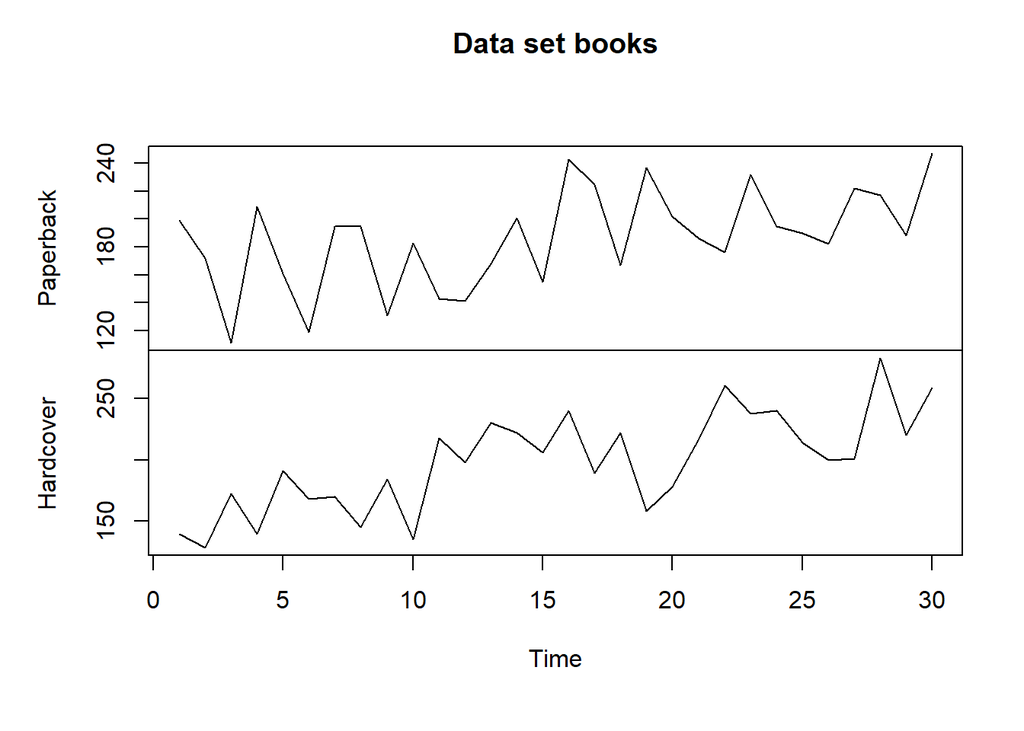

```r
plot(books, main = "Data set books")
```

- The data has upward trend, which is probably linear.
- The data has cyclic structure, although seasonality is not present.

Within-sample SSE for the one-step forecasts for paperback books

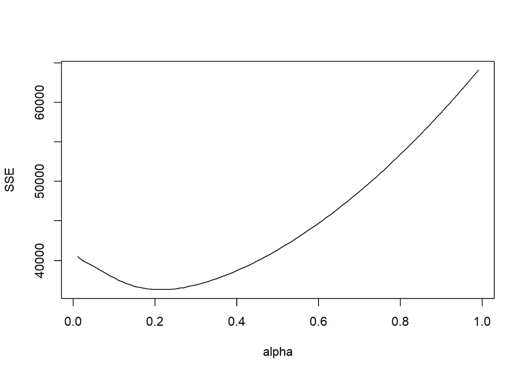

```r
alpha = seq(0.01, 0.99, 0.01) # Vector of values from 0.01 to 0.99 with step 0.01

# Initialization of variable SSE with a single value NA.
# Later variable SSE will be a vector containing sums of squared errors for different values of alpha.
SSE = NA

# Iterate through all values of vector alpha
for(i in seq_along(alpha)) {
  fcast = ses(books[,"Paperback"], alpha = alpha[i], initial = "simple")
  SSE[i] = sum((books[,"Paperback"] - fcast$fitted)^2)
}

# Plot of sums of squared errors calculated for different values alpha
plot(alpha, SSE, type = "l")
```

- Parameter alpha affects accuracy of within-sample one-step forecasts.
- The best accuracy of within-sample one-step forecasts is achieved for alpha approximately equal to $0.2$.

Best value of alpha and 4 days ahead forecast for paperback books

Setting initial = “simple”

```r
fcastPaperSimple = ses(books[,"Paperback"], initial = "simple", h = 4) # 4 days ahead forecast
# Chosen alpha can be accessed this way:
fcastPaperSimple$model$par[1]
```

```
    alpha
0.2125115
```

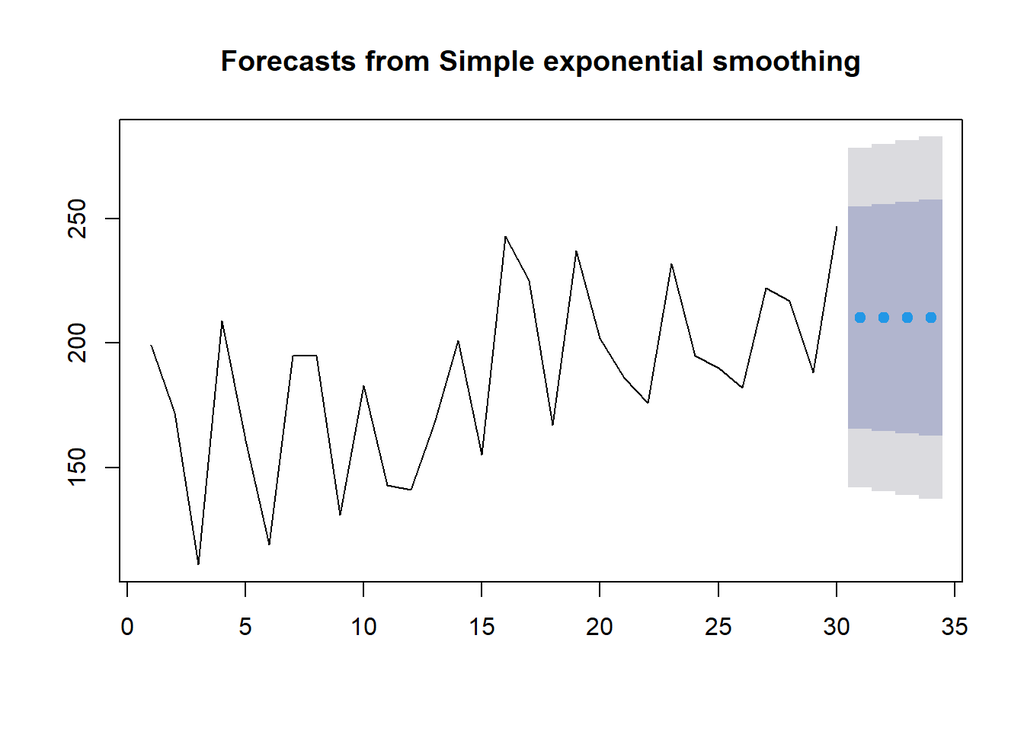

```r
plot(fcastPaperSimple)
```

Setting initial = “optimal”

```r
fcastPaperOpt = ses(books[,"Paperback"], initial = "optimal", h = 4)
fcastPaperOpt$model$par[1]
```

```
    alpha
0.1685372
```

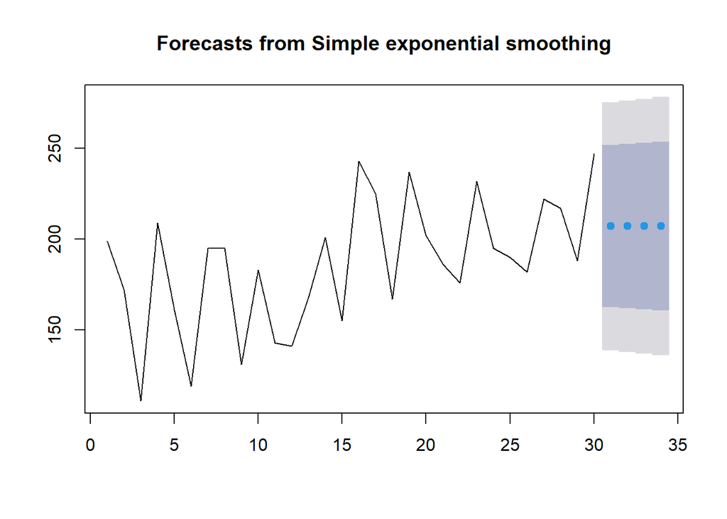

```r
plot(fcastPaperOpt)
```

Although the values alpha for different initial settings vary significantly, the final forecasts are almost identical:

```r
as.numeric((fcastPaperOpt$mean - fcastPaperSimple$mean)/fcastPaperSimple$mean) * 100 # In per cents
```

```
[1] -1.448492 -1.448492 -1.448492 -1.448492
```

Within-sample SSE for the one-step forecasts for hardcover books

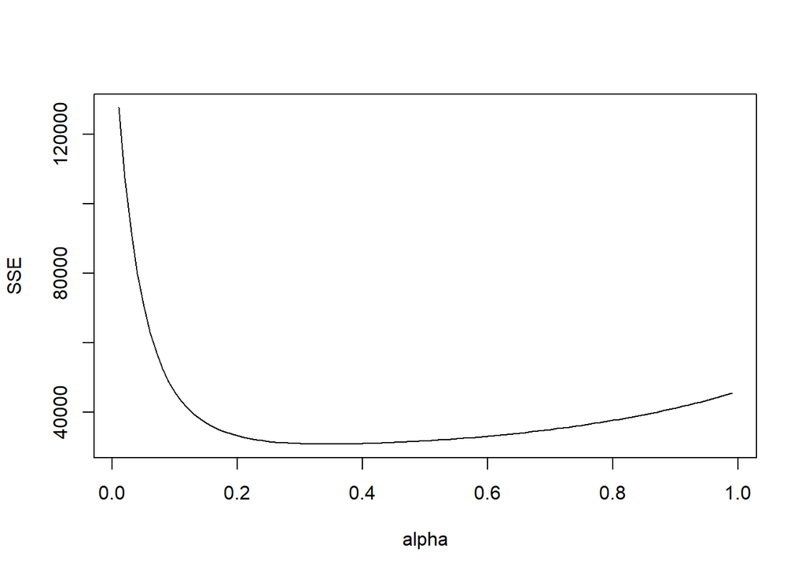

```r
alpha = seq(0.01, 0.99, 0.01) # Vector of values from 0.01 to 0.99 with step 0.01

# Initialization of variable SSE with a single value NA.
# Later variable SSE will be a vector containing sums of squared errors for different values of alpha.
SSE = NA

# Iterate through all values of vector alpha
for(i in seq_along(alpha)) {
  fcast = ses(books[,"Hardcover"], alpha = alpha[i], initial = "simple")
  SSE[i] = sum((books[,"Hardcover"] - fcast$fitted)^2)
}

# Plot of sums of squared errors calculated for different values alpha
plot(alpha, SSE, type = "l")
```

- Parameter alpha affects accuracy of within-sample one-step forecasts.
- The best accuracy of within-sample one-step forecasts is achieved for alpha approximately equal to $0.35$.

Best value of alpha and 4 days ahead forecast for hardcover books

Setting initial = “simple”

```r
fcastHardSimple = ses(books[,"Hardcover"], initial = "simple", h = 4) # 4 days ahead forecast
# Chosen alpha can be accessed this way:
fcastHardSimple$model$par[1]
```

```
    alpha
0.3473308
```

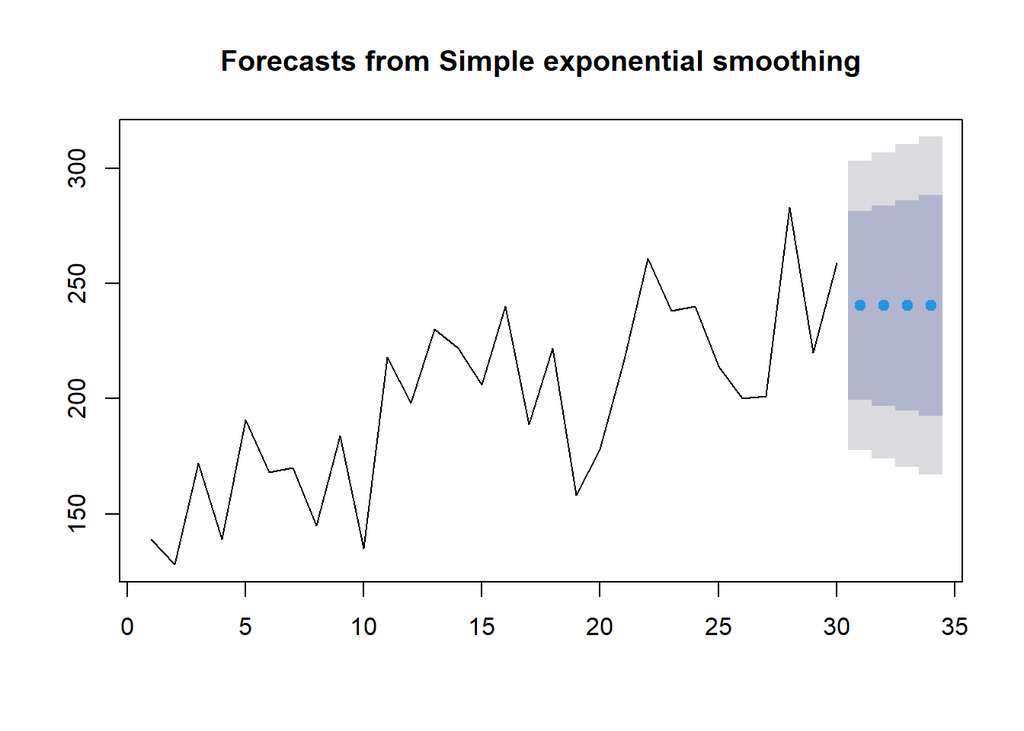

```r
plot(fcastHardSimple)
```

Setting initial = “optimal”

```r
fcastHardOpt = ses(books[,"Hardcover"], initial = "optimal", h = 4)
fcastHardOpt$model$par[1]
```

```
    alpha
0.3282665
```

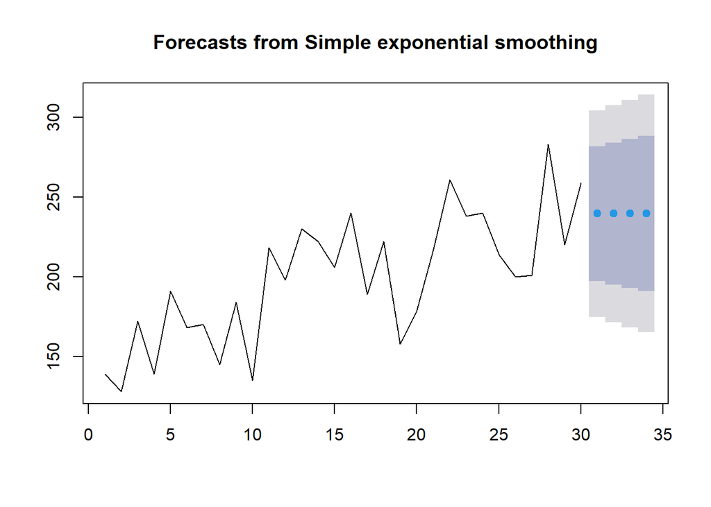

```r
plot(fcastHardOpt)
```

```r
as.numeric((fcastHardOpt$mean - fcastHardSimple$mean)/fcastHardSimple$mean) * 100 # In per cents
```

```
[1] -0.3414115 -0.3414115 -0.3414115 -0.3414115
```

## Exercise 7.2

Four-day forecasts of the paperback and hardback series using Holt’s linear method

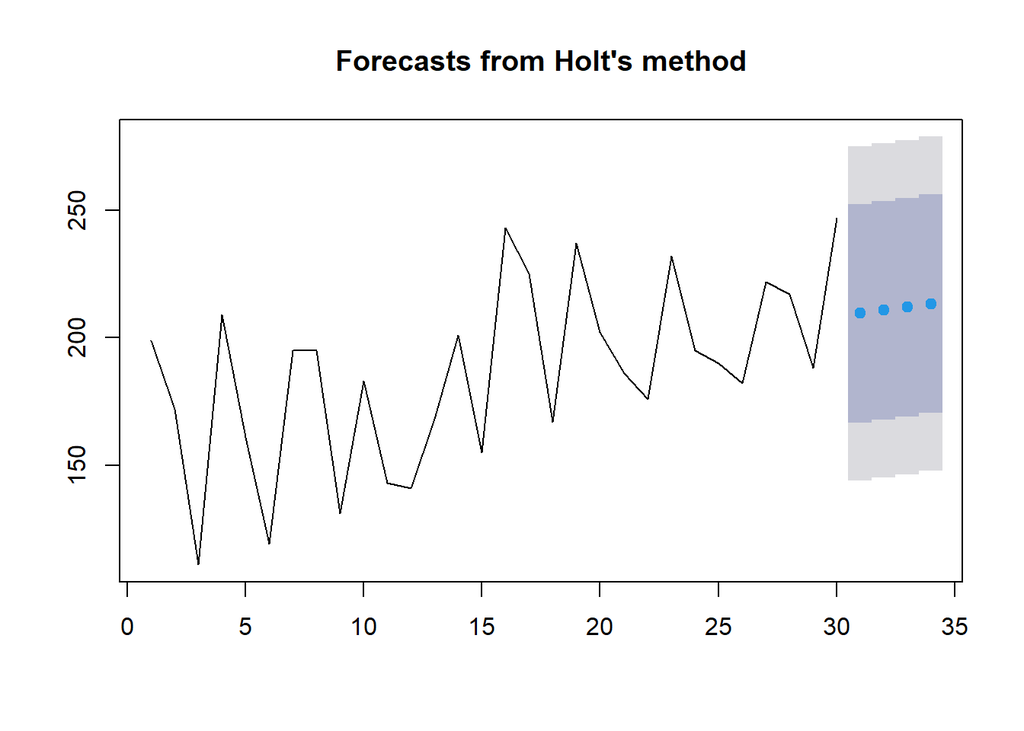

```r
fcastPaperHolt = holt(books[,"Paperback"], h=4)
plot(fcastPaperHolt)
```

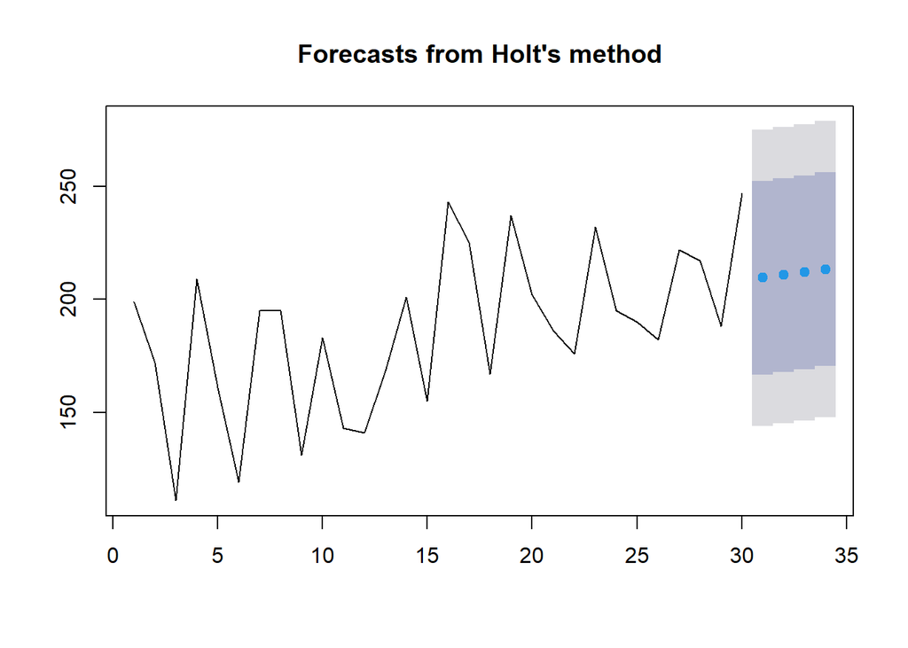

```r
fcastHardHolt = holt(books[,"Hardcover"], h=4)
plot(fcastPaperHolt)
```

Comparison of simple exponential smoothing and Holt’s linear methods

```r
SSEPaperOpt = sum(fcastPaperOpt$residuals^2)
SSEPaperHolt = sum(fcastPaperHolt$residuals^2)
```

```r
SSEPaperOpt
```

```
[1] 33944.82
```

```r
SSEPaperHolt
```

```
[1] 29085.24
```

```r
SSEHardOpt = sum(fcastHardOpt$residuals^2)
SSEHardHolt = sum(fcastHardHolt$residuals^2)
```

```r
SSEHardOpt
```

```
[1] 30587.69
```

```r
SSEHardHolt
```

```
[1] 22184.72
```

Sums of squared errors are much smaller for Holt’s linear method rather than for simple exponential smoothing method in both cases: for Paperback and Hardcover series.

It is clear that Holt’s linear method takes into account presence of the upward trend in the data. It leads to a better fit (better one step ahead forecasts).

### Comparison of the forecasts for the two series using both methods

#### Paperback series

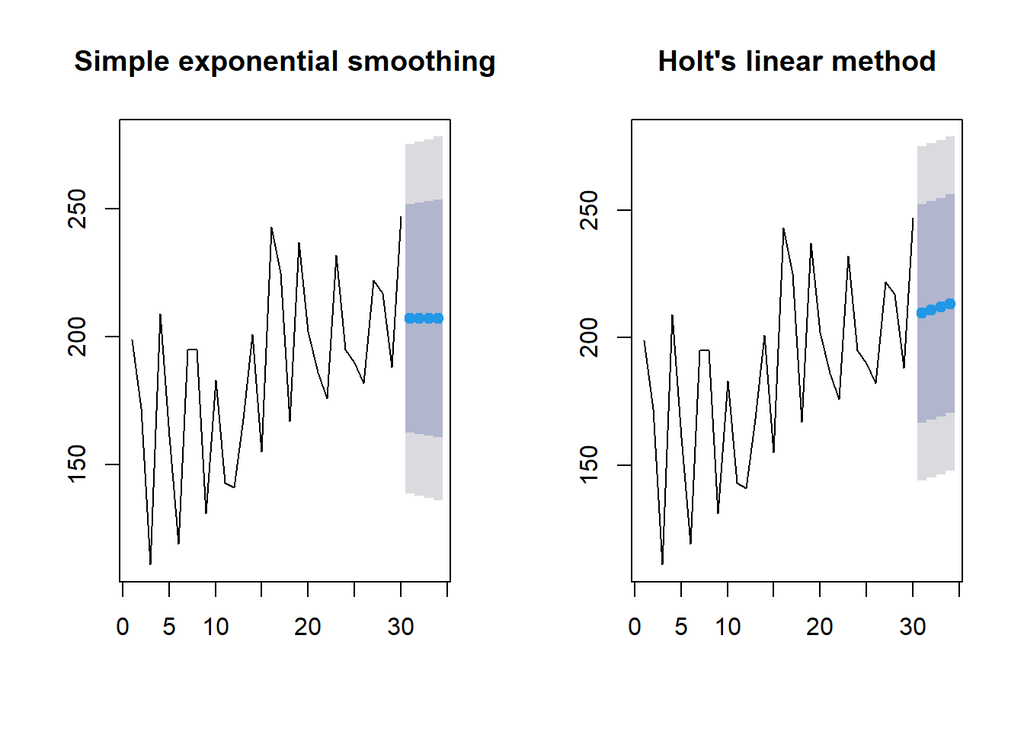

```r
par(mfrow=c(1,2)) # This line positions plots side-by-side
plot(fcastPaperOpt, main = "Simple exponential smoothing")
plot(fcastPaperHolt, main = "Holt's linear method")
```

#### Hardcover series

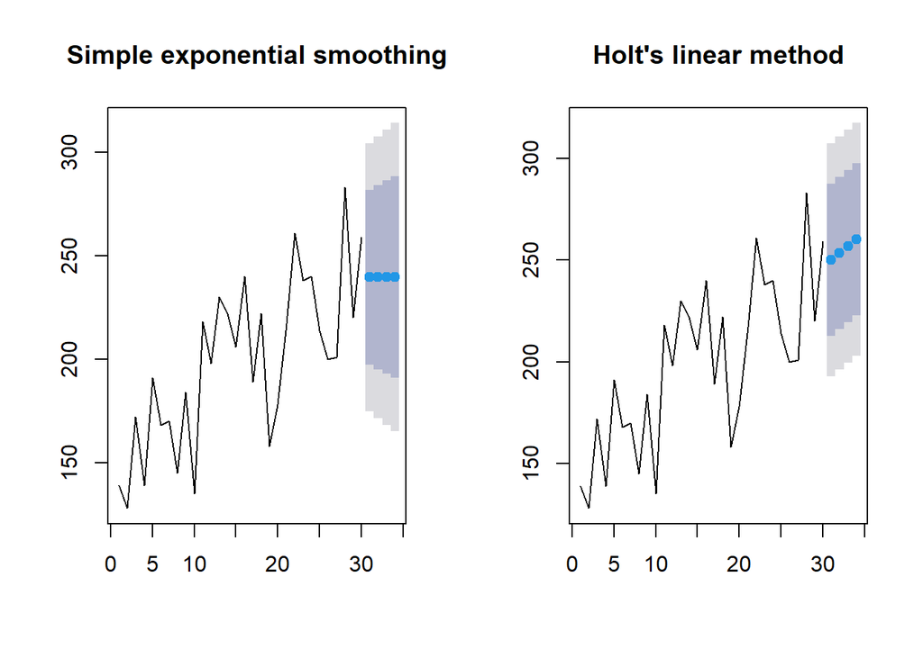

```r
par(mfrow=c(1,2)) # This line positions plots side-by-side
plot(fcastHardOpt, main = "Simple exponential smoothing")
plot(fcastHardHolt, main = "Holt's linear method")
```

Probably, in both cases, Holt’s linear method will predict better than simple exponential smoothing method. It is because Holt’s method takes into account clear upward trend in the data, while simple exponential smoothing does not.

### 95% prediction interval for the first forecast for each series using both methods (normal errors are assumed)

#### Paperback series, simple exponential smoothing method

```r
intLength = qnorm(0.975, sd = sqrt(fcastPaperOpt$model$mse))
High = fcastPaperOpt$mean[1] + intLength
Low = fcastPaperOpt$mean[1] - intLength
# The result is presented as a vector where elements are named
# The first two elements are the prediction interval calculated above
# The last two elements are the prediction interval calculated by ses method
c(Low = Low, High = High, RLow = fcastPaperOpt$lower[1,2], RHigh = fcastPaperOpt$upper[1,2])
```

```
      Low      High  RLow.95% RHigh.95%
 141.1810  273.0383  138.8670  275.3523
```

#### Paperback series, Holt’s linear method

```r
intLength = qnorm(0.975, sd = sqrt(fcastPaperHolt$model$mse))
High = fcastPaperHolt$mean[1] + intLength
Low = fcastPaperHolt$mean[1] - intLength
c(Low = Low, High = High, RLow = fcastPaperHolt$lower[1,2], RHigh = fcastPaperHolt$upper[1,2])
```

```
      Low      High  RLow.95% RHigh.95%
 148.4395  270.4940  143.9130  275.0205
```

#### Hardcover series, simple exponential smoothing method

```r
intLength = qnorm(0.975, sd = sqrt(fcastHardOpt$model$mse))
High = fcastHardOpt$mean[1] + intLength
Low = fcastHardOpt$mean[1] - intLength
c(Low = Low, High = High, RLow = fcastHardOpt$lower[1,2], RHigh = fcastHardOpt$upper[1,2])
```

```
      Low      High  RLow.95% RHigh.95%
 176.9765  302.1437  174.7799  304.3403
```

#### Hardcover series, Holt’s linear method

```r
intLength = qnorm(0.975, sd = sqrt(fcastHardHolt$model$mse))
High = fcastHardHolt$mean[1] + intLength
Low = fcastHardHolt$mean[1] - intLength
c(Low = Low, High = High, RLow = fcastHardHolt$lower[1,2], RHigh = fcastHardHolt$upper[1,2])
```

```
      Low      High  RLow.95% RHigh.95%
 196.8754  303.4723  192.9222  307.4256
```

```r
ukcars
```

```
        Qtr1    Qtr2    Qtr3    Qtr4
1977 330.371 371.051 270.670 343.880
1978 358.491 362.822 261.281 240.355
1979 325.382 316.700 171.153 257.217
1980 298.127 251.464 181.555 192.598
1981 245.652 245.526 225.261 238.211
1982 257.385 228.461 175.371 226.462
1983 266.150 287.251 225.883 265.313
1984 272.759 234.134 196.462 205.551
1985 291.283 284.422 221.571 250.697
1986 253.757 267.016 220.388 277.801
1987 283.233 302.072 259.720 297.658
1988 306.129 322.106 256.723 341.877
1989 356.004 361.540 270.433 311.105
1990 326.688 327.059 274.257 367.606
1991 346.163 348.211 250.008 292.518
1992 343.318 343.429 275.386 329.747
1993 364.521 378.448 300.798 331.757
1994 362.536 389.133 323.322 391.832
1995 421.646 416.823 311.713 381.902
1996 422.982 427.722 376.850 458.580
1997 436.225 441.487 369.566 450.723
1998 462.442 468.232 403.636 413.948
1999 460.496 448.932 407.787 469.408
2000 494.311 433.240 335.106 378.795
2001 387.100 372.395 335.790 397.080
2002 449.755 402.252 391.847 385.890
2003 424.325 433.280 391.213 408.740
2004 445.458 428.202 379.048 394.042
2005 432.796
```

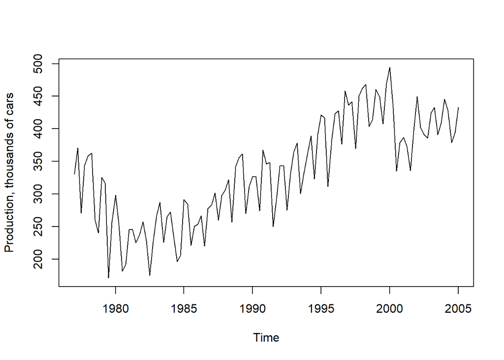

```r
plot(ukcars, ylab = "Production, thousands of cars")
```

- The data is seasonal
- Some nonlinear trend

### Decomposition of the series using STL

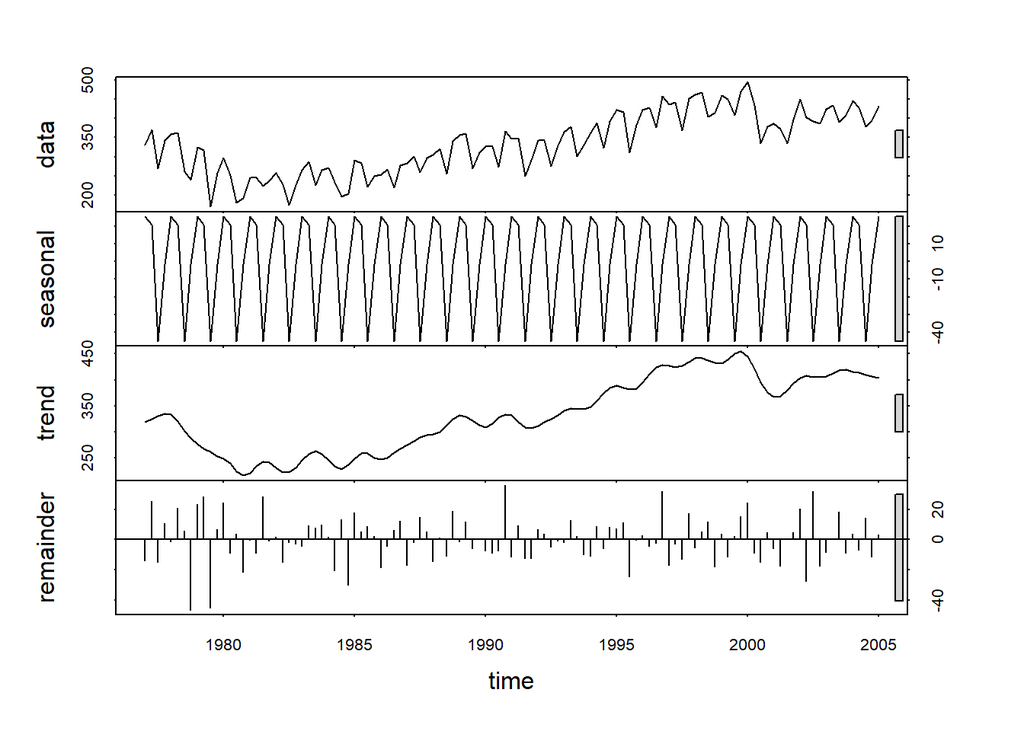

```r
stlFit <- stl(ukcars, s.window = "periodic")
plot(stlFit)
```

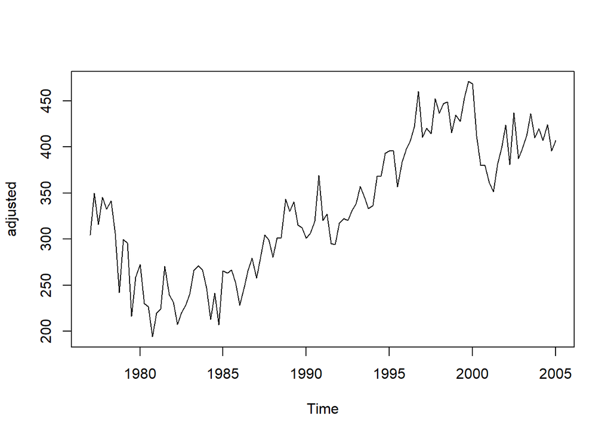

```r
adjusted <- seasadj(stlFit)
plot(adjusted)
```

### Two years forecast of the series using an additive damped trend method applied to the seasonally adjusted data. Then the forecasts are reseasonalized.

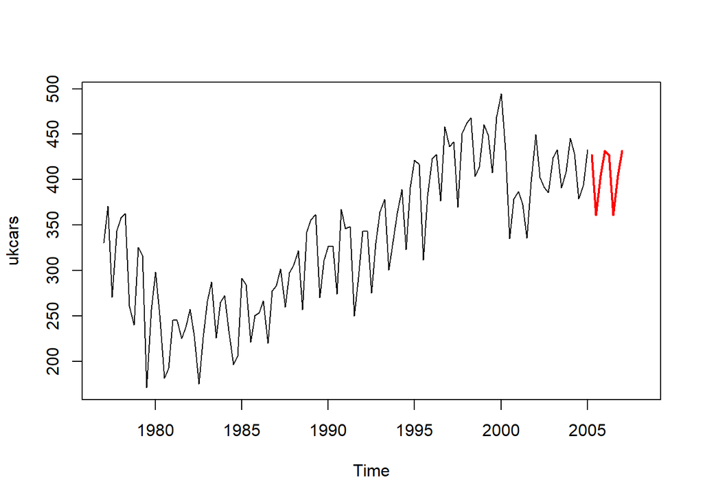

```r
fcastHoltDamp = holt(adjusted, damped=TRUE, h = 8)
plot(ukcars, xlim = c(1977, 2008))
lines(fcastHoltDamp$mean + stlFit$time.series[2:9,"seasonal"], col = "red", lwd = 2)
```

#### RMSE of one step forecasts

```r
dampHoltRMSE = sqrt(mean(((fcastHoltDamp$fitted + stlFit$time.series[,"seasonal"]) - ukcars)^2))
dampHoltRMSE
```

```
[1] 25.15986
```

### Two years forecast of the series using Holt’s linear trend method applied to the seasonally adjusted data. Then the forecasts are reseasonalized.

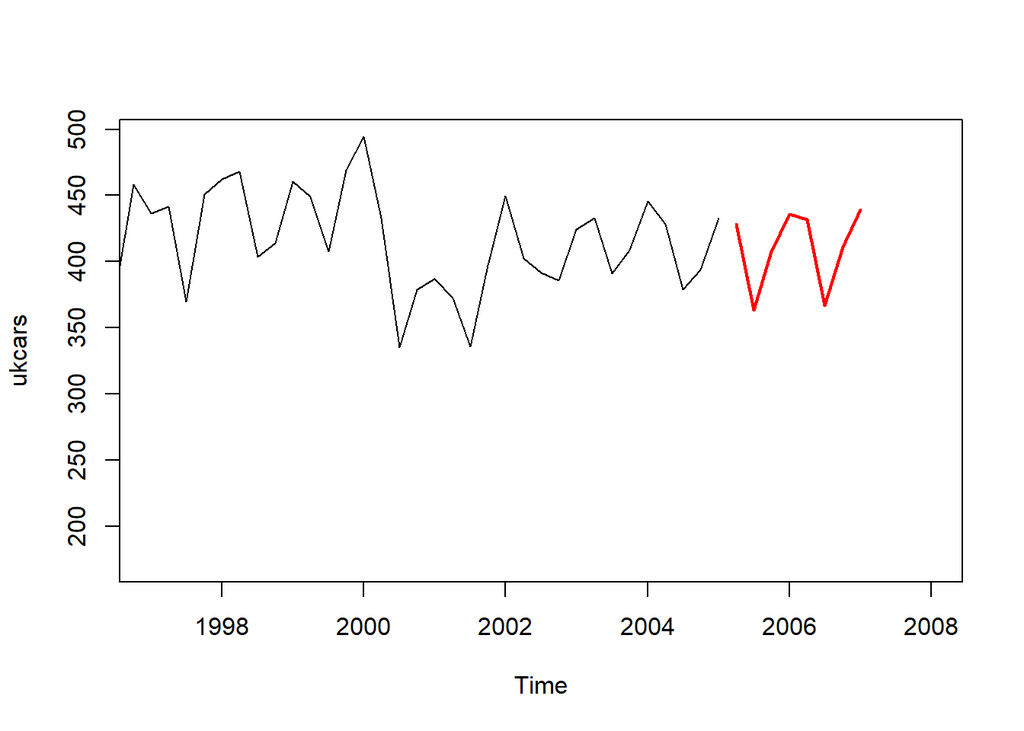

```r
fcastHolt = holt(adjusted, h = 8)
plot(ukcars, xlim = c(1997, 2008))
lines(fcastHolt$mean + stlFit$time.series[2:9,"seasonal"], col = "red", lwd = 2)
```

#### RMSE of one step forecasts

```r
holtRMSE = sqrt(mean(((fcastHolt$fitted + stlFit$time.series[,"seasonal"]) - ukcars)^2))
holtRMSE
```

```
[1] 25.26041
```

### Two years forecast of the series using ets method

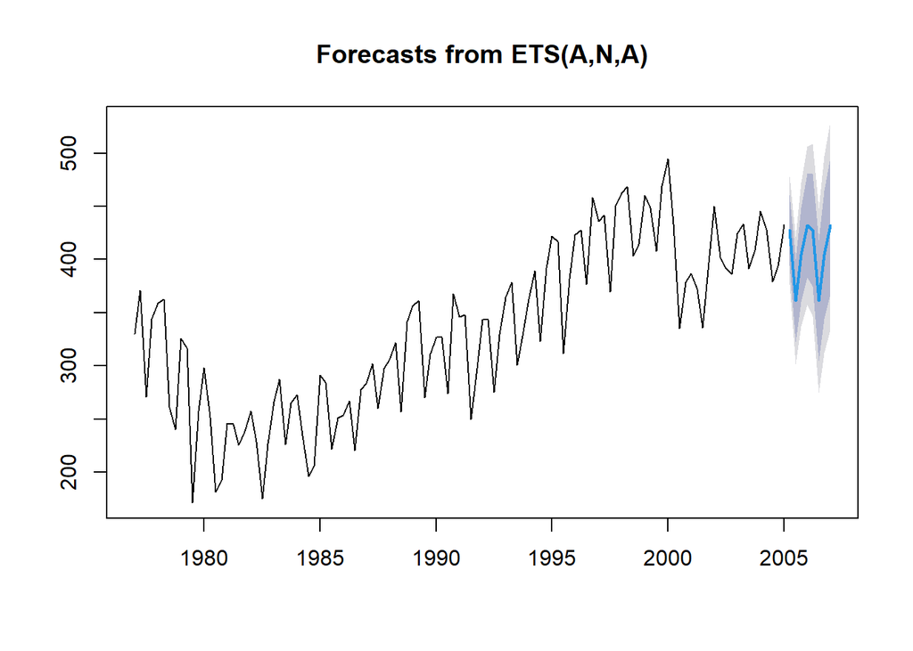

```r
etsFit = ets(ukcars)
fcastEts = forecast(etsFit, h = 8)
plot(fcastEts)
```

#### RMSE of one step forecasts

```r
etsRMSE = sqrt(mean((fcastEts$fitted - ukcars)^2))
etsRMSE
```

```
[1] 25.23244
```

### RMSE of the Holt’s method and ets forecasts

```r
c(HoltRMSE = holtRMSE, EtsRMSE = etsRMSE)
```

```
HoltRMSE  EtsRMSE
25.26041 25.23244
```

## Exercise 7.4

### Dataset visitors

```r
visitors
```

```
       Jan   Feb   Mar   Apr   May   Jun   Jul   Aug   Sep   Oct   Nov   Dec
1985                          75.7  75.4  83.1  82.9  77.3 105.7 121.9 150.0
1986  98.0 118.0 129.5 110.6  91.7  94.8 109.5 105.1  95.0 130.3 156.7 190.1
1987 139.7 147.8 145.2 132.7 120.7 116.5 142.0 140.4 128.0 165.7 183.1 222.8
1988 161.3 180.4 185.2 160.5 157.1 163.8 203.3 196.9 179.6 207.3 208.0 245.8
1989 168.9 191.1 180.0 160.1 136.6 142.7 175.4 161.4 149.9 174.1 192.7 247.4
1990 176.2 192.8 189.1 181.1 149.9 157.3 185.3 178.2 162.7 190.6 198.6 253.1
1991 177.4 190.6 189.2 168.0 161.4 172.2 208.3 199.3 197.4 216.0 223.9 266.8
1992 196.1 238.2 217.8 203.8 175.2 176.9 219.3 199.1 190.0 229.3 255.0 302.4
1993 242.8 245.5 257.9 226.3 213.4 204.6 244.6 239.9 224.0 267.2 285.9 344.0
1994 250.5 304.3 307.4 255.1 214.9 230.9 282.5 265.4 254.0 301.6 311.0 384.0
1995 303.8 319.1 313.5 294.2 244.8 261.4 329.7 304.9 268.6 320.7 342.9 422.3
1996 317.2 392.7 365.6 333.2 261.5 306.9 358.2 329.2 309.2 350.4 375.6 465.2
1997 342.9 408.0 390.9 325.9 289.1 308.2 397.4 330.4 330.9 366.5 379.5 448.3
1998 346.2 353.6 338.6 341.1 283.4 304.2 372.3 323.7 323.9 354.8 367.9 457.6
1999 351.0 398.6 389.0 334.1 298.1 317.1 388.5 355.6 353.1 397.0 416.7 460.8
2000 360.8 434.6 411.9 405.6 319.3 347.9 429.0 372.9 403.0 426.5 459.9 559.9
2001 416.6 429.2 428.7 405.4 330.2 370.0 446.9 384.6 366.3 378.5 376.2 523.2
2002 379.3 437.2 446.5 360.3 329.9 339.4 418.2 371.9 358.6 428.9 437.0 534.0
2003 396.6 427.5 392.5 321.5 260.9 308.3 415.5 362.2 385.6 435.3 473.3 566.6
2004 420.2 454.8 432.3 402.8 341.3 367.3 472.0 405.8 395.6 449.9 479.9 593.1
2005 462.4 501.6 504.7 409.5
```

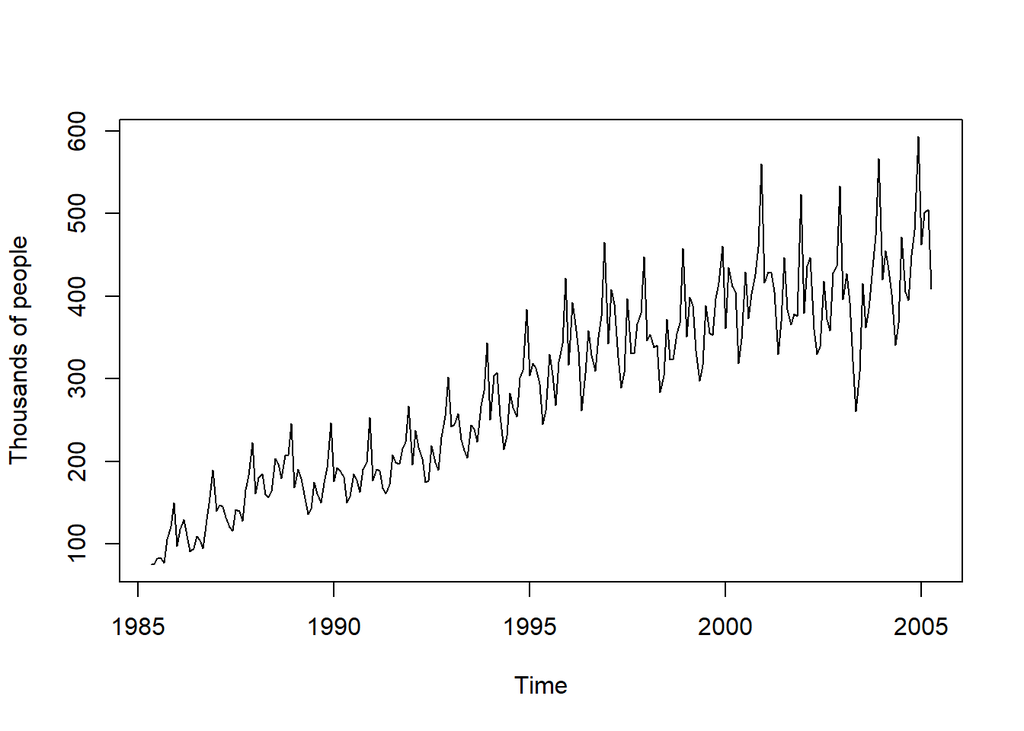

```r
plot(visitors, ylab = "Thousands of people")
```

- The data has upward trend.
- The data has seasonal pattern which increases it’s size approximately proportionally to the average number of people arrived per year. Therefore, it can be claimed, that the data has multiplicative seasonality.

### Forecast of the next two years using Holt-Winters’ multiplicative method.

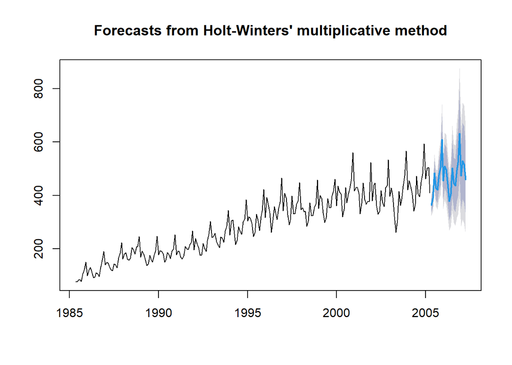

```r
fcast = hw(visitors, h=24, seasonal="multiplicative")
plot(fcast)
```

The multiplicative seasonality is important in this example. It reflects and then projects the behaviour of the seasonal pattern, which increases in size proportionally to the level of the trend.

### Experimenting with exponential and/or damped trends.

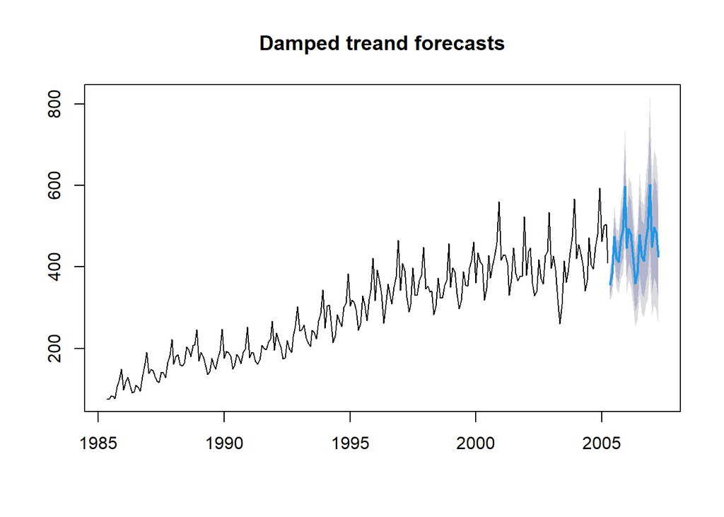

```r
fcastDamp = hw(visitors, h=24, seasonal="multiplicative", damped=TRUE, exponential=FALSE)
plot(fcastDamp, main = "Damped treand forecasts")
```

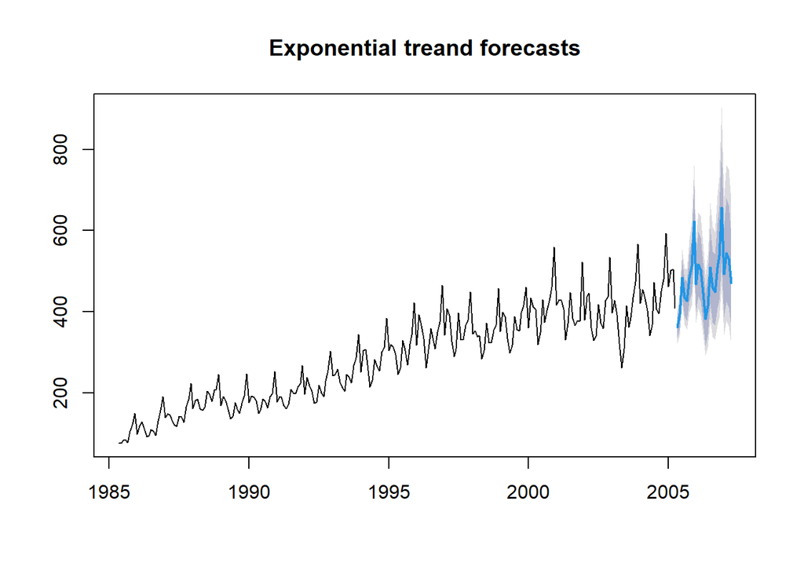

```r
fcastExp = hw(visitors, h=24, seasonal="multiplicative", damped=FALSE, exponential=TRUE)
plot(fcastExp, main = "Exponential treand forecasts")
```

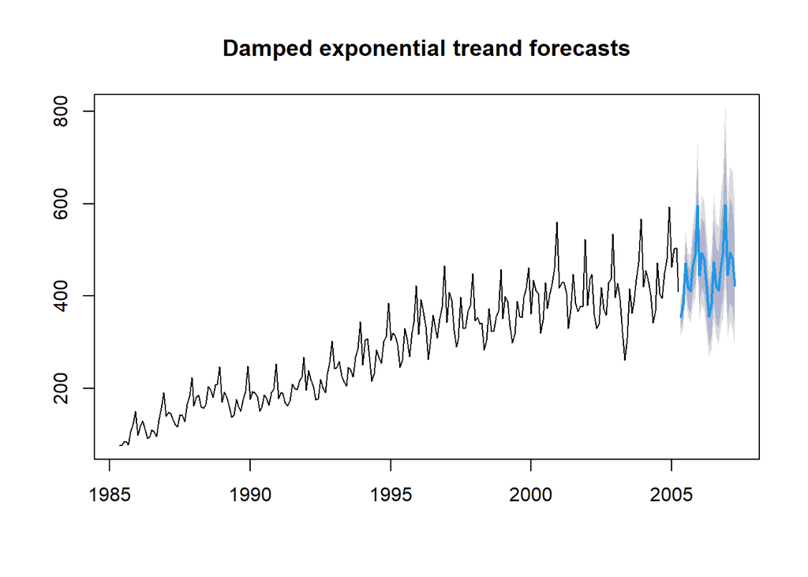

```r
fcastDampExp = hw(visitors, h=24, seasonal="multiplicative", damped=TRUE, exponential=TRUE)
plot(fcastDampExp, main = "Damped exponential treand forecasts")
```

Different methods project the trend differently into the future. Although the short term forecasts are not very different, the long term forecasts will change a lot.

### Comparing the RMSE of the one-step forecasts from the above methods.

```r
c(RMSE = sqrt(fcast$model$mse), RMSEDamp = sqrt(fcastDamp$model$mse), RMSEExp = sqrt(fcastExp$model$mse), RMSEDampExp = sqrt(fcastDampExp$model$mse))
```

```
       RMSE    RMSEDamp     RMSEExp RMSEDampExp
   14.66220    14.41189    14.62367    14.42116
```

Damped trend method fits the data better than the other methods (in terms of RMSE of one-step ahead forecasts over the whole data set). If we assume that the methods are approximately same complex, we can expect that the damped trend method will forecast better than the other methods beyond the training data.

### Residual diagnostics and forecasts for the next two years for different methods.

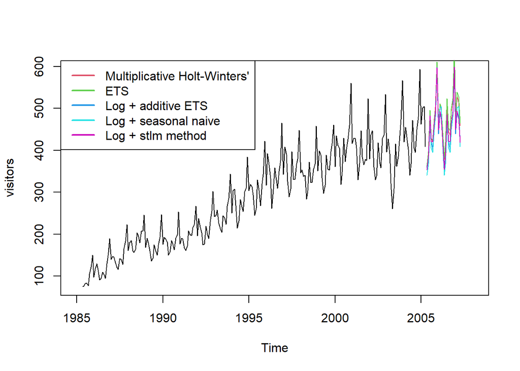

```r
# Multiplicative Holt-Winters' method
fcasHW = hw(visitors, h=24, seasonal="multiplicative")

# ETS model
fitETS = ets(visitors)
fcastETS = forecast(fitETS, h = 24)

# Additive ETS model applied to a Box-Cox transformed series
fitETSlog = ets(visitors, lambda = 0, model = "AAA")
fcastETSlog = forecast(fitETSlog, h = 24)

# Seasonal naive method applied to the Box-Cox transformed series
fcastSnaiveLog = snaive(visitors, h = 24, lambda = 0)

# STL decomposition applied to the Box-Cox transformed data
# followed by an ETS model applied to the seasonally adjusted (transformed) data
fitStlm = stlm(visitors, method = "ets", lambda = 0)
fcastStlm = forecast(fitStlm, h = 24)

# Plotting all forecasts
plot(visitors, xlim = c(1985, 2008))
lines(fcasHW$mean, col = 2)
lines(fcastETS$mean, col = 3)
lines(fcastETSlog$mean, col = 4)
lines(fcastSnaiveLog$mean, col = 5)
lines(fcastStlm$mean, col = 6)
legend("topleft",
       legend = c("Multiplicative Holt-Winters'", "ETS", "Log + additive ETS",
                  "Log + seasonal naive", "Log + stlm method"),
       col = 2:6, lwd = 2)
```

The forecasts look very similar.

### Residual diagnostics

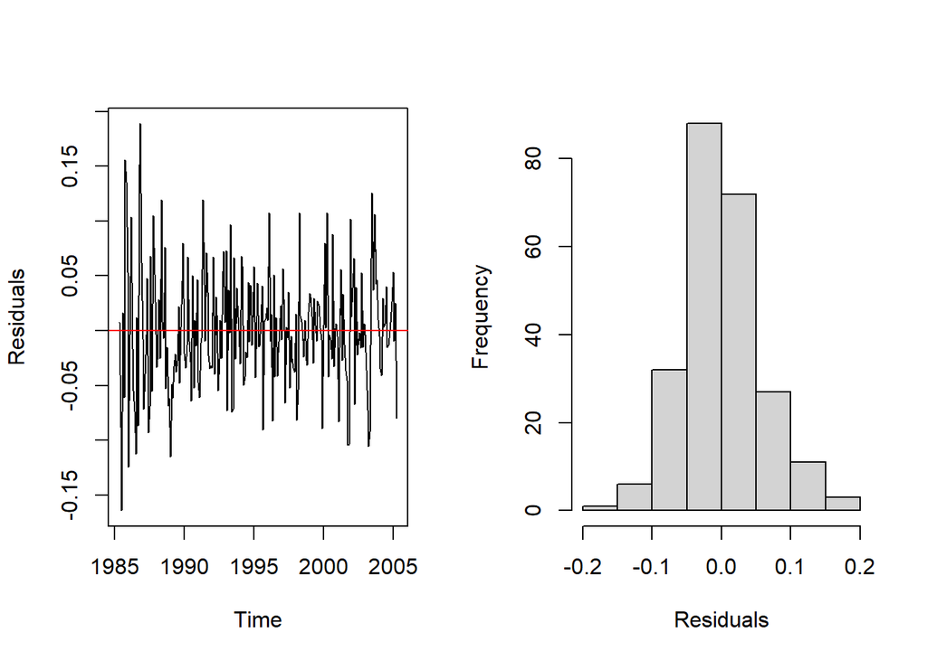

```r
# Plotting the residuals
par(mfrow=c(1,2)) # This line positions two consequent plots side-by-side
plot(fcasHW$residuals, ylab = "Residuals")
abline(h = 0, col = "red")
hist(fcasHW$residuals, main = "", xlab = "Residuals")
```

The residuals positively scewed. They might be serially correlated.

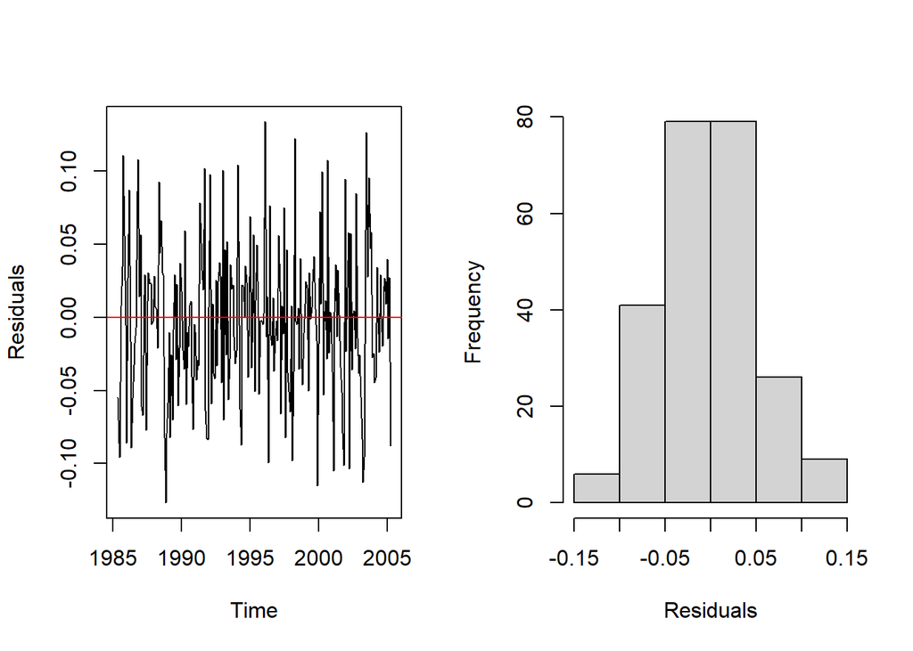

```r
par(mfrow=c(1,2))
plot(fcastETS$residuals, ylab = "Residuals")
abline(h = 0, col = "red")
hist(fcastETS$residuals, main = "", xlab = "Residuals")
```

The residuals might be serially correlated. The distribution looks normal.

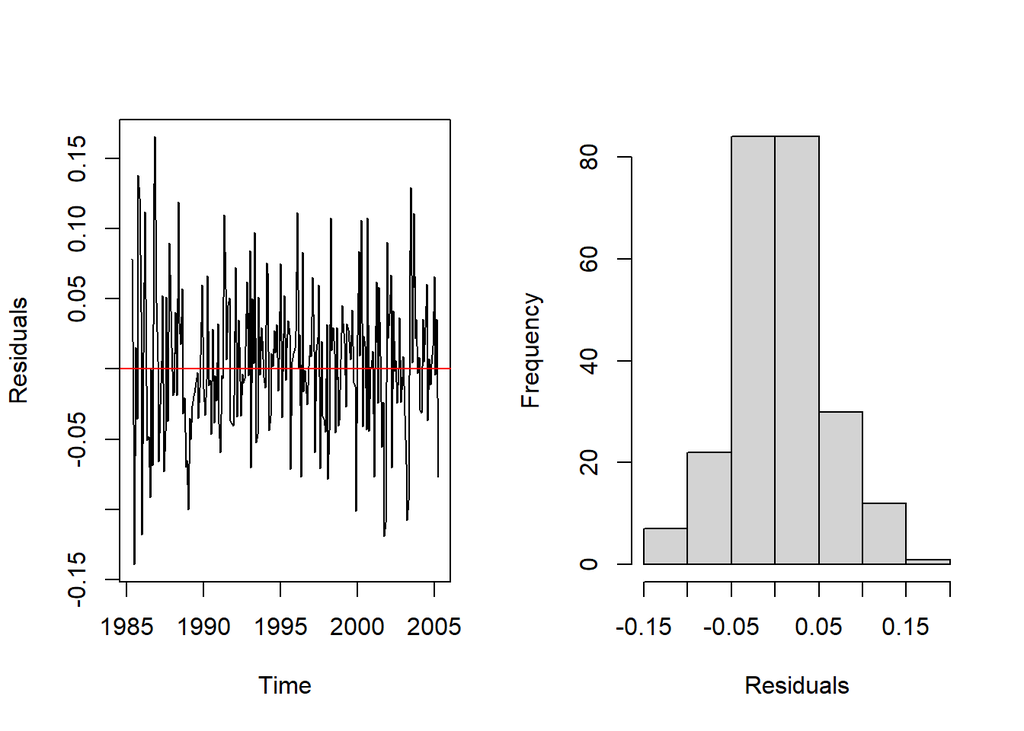

```r
par(mfrow=c(1,2))
plot(fcastETSlog$residuals, ylab = "Residuals")
abline(h = 0, col = "red")
hist(fcastETSlog$residuals, main = "", xlab = "Residuals")
```

The residuals might be serially correlated. The distribution looks rather normal.

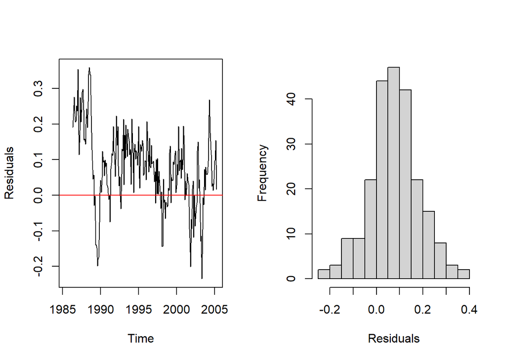

```r
par(mfrow=c(1,2))
plot(fcastSnaiveLog$residuals, ylab = "Residuals")
abline(h = 0, col = "red")
hist(fcastSnaiveLog$residuals, main = "", xlab = "Residuals")
```

The residuals are positively biased and serially correlated.

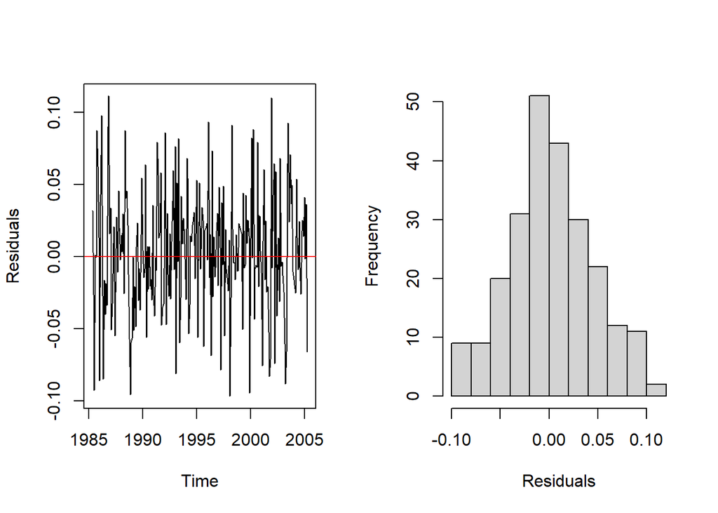

```r
par(mfrow=c(1,2))
plot(fcastStlm$residuals, ylab = "Residuals")
abline(h = 0, col = "red")
hist(fcastStlm$residuals, main = "", xlab = "Residuals")
```

Although the residuals look a little bit serially correlated for the last method, they are smallest in size among the considered models. Assuming that all methods approximately same complex, the last method is the most promising for forecasting.